# Lecture 10

2026-04-30

## Activity 1 (Always Anonymous)

### QR Code or link

This is anonymous & optional, but helpful to Stats 20,

[figure not shown]

or here is a [direct link](https://www.menti.com/bl3ovtgc28d7)

# THERE IS NO MIDTERM

# But let’s review and plug some gaps

# Extracting Information from Data Structures

## Subsetting, using `[` - Data Frame

- The single bracket works on any data structure. The key is understanding what it is being applied to (input) and what is the result (output).
- This example involves a **data frame**, recall `df[row(s), column(s)]` will extract specific rows and columns if given them by name or by position (number or index)

```r
EQ2025 <- read.table("https://service.scedc.caltech.edu/ftp/catalogs/SCEC_DC/2025.catalog",
                          col.names = c("DATE", "TIME", "EVENT_TYPE", "GT", "MAG","MAGTYPE","LAT",
                                        "LON", "DEPTH", "QUALITY", "EVENT_ID", "Num_Phases",
                                        "Num_Grams"))
str(EQ2025)
```

```
'data.frame':   16818 obs. of  13 variables:
 $ DATE      : chr  "2025/01/01" "2025/01/01" "2025/01/01" "2025/01/01" ...
 $ TIME      : chr  "01:00:56.92" "01:16:28.99" "01:30:49.87" "01:54:51.66" ...
 $ EVENT_TYPE: chr  "eq" "eq" "eq" "eq" ...
 $ GT        : chr  "l" "l" "l" "l" ...
 $ MAG       : num  0.59 1.21 0.6 1.06 0.57 0.96 0.9 0.58 0.85 0.51 ...
 $ MAGTYPE   : chr  "l" "l" "l" "l" ...
 $ LAT       : num  33.3 34 34.1 35.5 33.5 ...
 $ LON       : num  -116 -117 -118 -118 -117 ...
 $ DEPTH     : num  3.3 13.4 12.2 8.6 5.9 10.2 8.8 7.9 4.9 10.9 ...
 $ QUALITY   : chr  "A" "A" "A" "A" ...
 $ EVENT_ID  : int  40831087 40831095 40831103 40831111 40831119 40831127 40831135 40831151 40831159 40831167 ...
 $ Num_Phases: int  7 94 18 49 58 96 74 41 35 44 ...
 $ Num_Grams : int  1005 2122 1834 1442 1125 1472 1194 1106 1557 1880 ...
```

## Subsetting, using `[` - Specifying columns

- With a data frame, we could use it to extract single vectors or multiple vectors, the single vector result will be a vector, multiple vectors return a data frame.

```r
mag1 <- EQ2025[ , 5] # column 5, all rows
mag2 <- EQ2025[ , "MAG"] # name of the column, all rows
paste("Compare mag1 and mag2", all.equal(mag1, mag2))
```

```
[1] "Compare mag1 and mag2 TRUE"
```

```r
is(mag1)
```

```
[1] "numeric" "vector"
```

```r
mag_qual1 <- EQ2025[ , c(5, 10)]  # columns 5 and 10, all rows
mag_qual2 <- EQ2025[ , c("MAG", "QUALITY")]
mag_qual3 <- EQ2025[ , c("QUALITY", "MAG")] # switched, you can order things the way you want
paste("Are mag_qual1 and mag_qual2 the same?", all.equal(mag_qual1, mag_qual2))
```

```
[1] "Are mag_qual1 and mag_qual2 the same? TRUE"
```

```r
paste("Are mag_qual2 and mag_qual3 the same?", all.equal(mag_qual2, mag_qual3))
```

```
[1] "Are mag_qual2 and mag_qual3 the same? Names: 2 string mismatches"
[2] "Are mag_qual2 and mag_qual3 the same? Component 1: Modes: numeric, character"
[3] "Are mag_qual2 and mag_qual3 the same? Component 1: target is numeric, current is character"
[4] "Are mag_qual2 and mag_qual3 the same? Component 2: Modes: character, numeric"
[5] "Are mag_qual2 and mag_qual3 the same? Component 2: target is character, current is numeric"
```

```r
is(mag_qual2)
```

```
[1] "data.frame" "list"       "oldClass"   "vector"
```

## Subsetting, using `[` - Specifying rows

- Of course you can always use row indices BUT we are at the point where you may wish to subset based on characteristics of the row instead of something like 1:10.

```r
mag3 <- EQ2025[EQ2025$MAG > 3, ] # The row values for the MAG column must be > 3, all columns

mag3safer <- EQ2025[which(EQ2025$MAG > 3), ] # name of the column, all rows

all.equal(mag3, mag3safer) # result is the same
```

```
[1] TRUE
```

```r
which(EQ2025$MAG > 3)
```

```
  [1]   273   367   475   557   678   878   902  1624  1636  1656  1746  1777
 [13]  1784  1793  1877  2040  2134  2342  2432  2565  2595  2724  2849  2986
 [25]  3391  3453  3475  3839  3902  3911  3969  4172  4231  4243  4343  4669
 [37]  4799  5248  5395  5670  6180  6608  6899  7200  7462  8602  8792  8793
 [49]  8826  8831  8858  9065  9286  9550  9865  9866  9992  9993 10120 10239
 [61] 10255 10274 10310 10328 10329 10333 10336 10528 10750 10788 10809 11679
 [73] 11943 12065 12121 12160 12295 12358 12362 12556 13054 13145 13203 13214
 [85] 13220 13932 13961 13997 14073 14082 14314 14794 14849 14879 14892 15144
 [97] 15186 15191 15192 15447 15648 15698 15823 15938 16076 16094 16105 16118
[109] 16181 16226
```

- The result of EQ2025$MAG > 3 gives us a vector of TRUE and FALSE for all rows
- which() will give us the exact row indices, it can be safer when you are using `==` or have NA, NaN values

## Using the `$`

- We can use it to extract vectors by their names (must be named)
- It is a little more readable but the tradeoff is more limitations

```r
MAG <- EQ2025$MAG # creates a vector unassociated with the data frame, free floating, can be confusing

## a better application
fivenum(EQ2025$MAG) # extracting a specific vector for analysis
```

```
[1] 0.00 0.71 0.99 1.34 5.21
```

```r
## you could extract further
fivenum(EQ2025$MAG[EQ2025$MAG > 3]) # vector EQ2025$MAG extract those MAG > 3
```

```
[1] 3.01 3.12 3.29 3.57 5.21
```

```r
## and use different information
table(EQ2025$QUALITY[EQ2025$MAG > 3]) # vector EQ2025$QUALITY extract those with MAG > 3
```

```
  A   B   C   D
103   1   4   2
```

## Subsetting a subset

This can look daunting, we are taking a subset of one variable given the values on a different variable in the last example on the previous slide.

```r
table(EQ2025$QUALITY[EQ2025$MAG > 3])
# compare EQ2025[EQ2025$MAG > 3, ] from above or EQ2025[EQ2025$MAG > 3, "QUALITY" ] or EQ2025[EQ2025$MAG > 3, 10 ]
```

This is where the “then” operator (`|>`) helps, we extract the exact subset we want and then `table()` the subset. The code is easier to read.

```r
EQ2025$QUALITY[EQ2025$MAG > 3] |> table()
```

- R does not look inside your data frame, you must explicitly reference columns (e.g., EQ2025$MAG) on the row side of [r, c]
- The second argument (columns) must be column indices or names, not the actual values of a column.

## Activity #2 Try it

Try some subsetting and ask questions

```r
# how do you calculate a five number summary for magnitude (MAG) given a depth (DEPTH) greater than 12km?
```

If your median (3rd value) was 0.89 that is correct.

## Subsetting, using `[[`

- `[[ ]]` extracts **exactly one element**
- and returns its contents (not the container/not the outer structure)
- uses position or names (if available).

```r
rivers[[141]] #  not the best use but an example
```

```
[1] 1770
```

```r
iris1N <- iris[["Sepal.Length"]] # a lot of typing for one column...
iris1P <- iris[[1]]
all.equal(iris1N, iris1P)
```

```
[1] TRUE
```

```r
is(iris1P)
```

```
[1] "numeric" "vector"
```

- IMO the best application is with lists

## List Example

- Extract the “pivot” (the column order used in model estimation for numerical stability)
- lm()
- extract
- You might ask why…
- finally!

```r
model1 <- lm(Fertility ~ Education, data = swiss)
str(model1)
```

```
List of 12
 $ coefficients : Named num [1:2] 79.61 -0.862
  ..- attr(*, "names")= chr [1:2] "(Intercept)" "Education"
 $ residuals    : Named num [1:47] 10.9 11.3 17.2 12.2 10.2 ...
  ..- attr(*, "names")= chr [1:47] "Courtelary" "Delemont" "Franches-Mnt" "Moutier" ...
 $ effects      : Named num [1:47] -480.9 -56.2 14.9 10.2 9.4 ...
  ..- attr(*, "names")= chr [1:47] "(Intercept)" "Education" "" "" ...
 $ rank         : int 2
 $ fitted.values: Named num [1:47] 69.3 71.8 75.3 73.6 66.7 ...
  ..- attr(*, "names")= chr [1:47] "Courtelary" "Delemont" "Franches-Mnt" "Moutier" ...
 $ assign       : int [1:2] 0 1
 $ qr           :List of 5
  ..$ qr   : num [1:47, 1:2] -6.856 0.146 0.146 0.146 0.146 ...
  .. ..- attr(*, "dimnames")=List of 2
  .. .. ..$ : chr [1:47] "Courtelary" "Delemont" "Franches-Mnt" "Moutier" ...
  .. .. ..$ : chr [1:2] "(Intercept)" "Education"
  .. ..- attr(*, "assign")= int [1:2] 0 1
  ..$ qraux: num [1:2] 1.15 1.03
  ..$ pivot: int [1:2] 1 2
  ..$ tol  : num 1e-07
  ..$ rank : int 2
  ..- attr(*, "class")= chr "qr"
 $ df.residual  : int 45
 $ xlevels      : Named list()
 $ call         : language lm(formula = Fertility ~ Education, data = swiss)
 $ terms        :Classes 'terms', 'formula'  language Fertility ~ Education
  .. ..- attr(*, "variables")= language list(Fertility, Education)
  .. ..- attr(*, "factors")= int [1:2, 1] 0 1
  .. .. ..- attr(*, "dimnames")=List of 2
  .. .. .. ..$ : chr [1:2] "Fertility" "Education"
  .. .. .. ..$ : chr "Education"
  .. ..- attr(*, "term.labels")= chr "Education"
  .. ..- attr(*, "order")= int 1
  .. ..- attr(*, "intercept")= int 1
  .. ..- attr(*, "response")= int 1
  .. ..- attr(*, ".Environment")=<environment: R_GlobalEnv>
  .. ..- attr(*, "predvars")= language list(Fertility, Education)
  .. ..- attr(*, "dataClasses")= Named chr [1:2] "numeric" "numeric"
  .. .. ..- attr(*, "names")= chr [1:2] "Fertility" "Education"
 $ model        :'data.frame':  47 obs. of  2 variables:
  ..$ Fertility: num [1:47] 80.2 83.1 92.5 85.8 76.9 76.1 83.8 92.4 82.4 82.9 ...
  ..$ Education: int [1:47] 12 9 5 7 15 7 7 8 7 13 ...
  ..- attr(*, "terms")=Classes 'terms', 'formula'  language Fertility ~ Education
  .. .. ..- attr(*, "variables")= language list(Fertility, Education)
  .. .. ..- attr(*, "factors")= int [1:2, 1] 0 1
  .. .. .. ..- attr(*, "dimnames")=List of 2
  .. .. .. .. ..$ : chr [1:2] "Fertility" "Education"
  .. .. .. .. ..$ : chr "Education"
  .. .. ..- attr(*, "term.labels")= chr "Education"
  .. .. ..- attr(*, "order")= int 1
  .. .. ..- attr(*, "intercept")= int 1
  .. .. ..- attr(*, "response")= int 1
  .. .. ..- attr(*, ".Environment")=<environment: R_GlobalEnv>
  .. .. ..- attr(*, "predvars")= language list(Fertility, Education)
  .. .. ..- attr(*, "dataClasses")= Named chr [1:2] "numeric" "numeric"
  .. .. .. ..- attr(*, "names")= chr [1:2] "Fertility" "Education"
 - attr(*, "class")= chr "lm"
```

```r
names(model1)
```

```
 [1] "coefficients"  "residuals"     "effects"       "rank"
 [5] "fitted.values" "assign"        "qr"            "df.residual"
 [9] "xlevels"       "call"          "terms"         "model"
```

```r
model1[["qr"]][["pivot"]] # notice, it extracts one component from many
```

```
[1] 1 2
```

```r
model1$qr$pivot # this works too though
```

```
[1] 1 2
```

```r
library(jsonlite)
junk <- read_json("http://www.stat.ucla.edu/~vlew/datasets/DataSift-49de7967b29ac130ab49248db140d634-1389311635.json") # from someone's interview about a decade ago
names(junk)
```

```
[1] "count"        "hash"         "hash_type"    "id"           "delivered_at"
[6] "interactions"
```

```r
str(junk$interactions)
```

[output not shown]

[output cut: 974 more lines]

[output not shown]

```r
length(junk$interactions)
```

```
[1] 18
```

```r
junk$interactions[[18]]
```

```
$demographic
$demographic$gender
[1] "mostly_female"


$interaction
$interaction$author
$interaction$author$avatar
[1] "http://a0.twimg.com/profile_images/2925087111/be30e521f9094325dab03551cdc67c3b_normal.jpeg"

$interaction$author$id
[1] 573265648

$interaction$author$link
[1] "http://twitter.com/LDeWoody"

$interaction$author$name
[1] "Lauren Marie"

$interaction$author$username
[1] "LDeWoody"


$interaction$content
[1] "#ERedCarpet Jennifer Lawrence &lt;333"

$interaction$created_at
[1] "Sun, 13 Jan 2013 23:09:12 +0000"

$interaction$id
[1] "1e25dd63e0d9ac00e074591d84d8000e"

$interaction$link
[1] "http://twitter.com/LDeWoody/statuses/290596386909614080"

$interaction$schema
$interaction$schema$version
[1] 3


```

[output cut: 69 more lines]

```

$twitter$user$profile_image_url
[1] "http://a0.twimg.com/profile_images/2925087111/be30e521f9094325dab03551cdc67c3b_normal.jpeg"

$twitter$user$screen_name
[1] "LDeWoody"

$twitter$user$statuses_count
[1] 815

$twitter$user$time_zone
[1] "Eastern Time (US & Canada)"

$twitter$user$utc_offset
[1] -18000
```

## Activity #3 Attendance

### Please Greet Your Neighbor(s)

- Practice in a low stakes environment. So it becomes natural.
- Reminder: You need at least one different neighbor each week for your attendance credit (only one photo required)
- Reminder: You cannot receive credit if it’s only you in the photo, please refrain from photoshopping/editing photos
- Reminder: You need to upload the photo for credit.
- Please try to greet & meet a new classmate, take a photograph.

## Even more data sources

[NOAA](https://www.ncei.noaa.gov/stormevents/)  
[International Disaster Database](https://www.emdat.be/)  
[FEMA](https://www.fema.gov/about/openfema/data-sets)  
[World Happiness Report](https://www.worldhappiness.report/data-sharing/)  
[UN Development Reports](https://hdr.undp.org/data-center)  
[Youth Behavioral Risk - CDC](https://www.cdc.gov/yrbs/index.html)  
[Opportunity Insights](https://opportunityinsights.org/data/)

# Relational Operators

## Braun & Murdoch Chapter 2.4.1

- Recall the Earthquake data. Suppose you were told to create a subset of data where the magnitude (MAG) must be at least 2.5 and the quality (QUALITY) must be “A”.
- How would you write the request?

```r
# this works but is horribly inefficient
# you don't want to be occupying so much of your resources

MAG25 <- EQ2025[EQ2025$MAG >= 2.5, ]
ANDQUALITYA <- MAG25[MAG25$QUALITY == "A",]
```

- Let’s spend a little time with the Boolean Algebra of R
- Wikipedia tells us: Introduced by George Boole, it uses operators like AND, OR, and NOT to model, analyze, and simplify logical expressions, forming the fundamental basis of digital circuit design and computer programming

## A Truth Table

- The body of this table shows how logical operations behave for every possible combination of TRUE and FALSE.

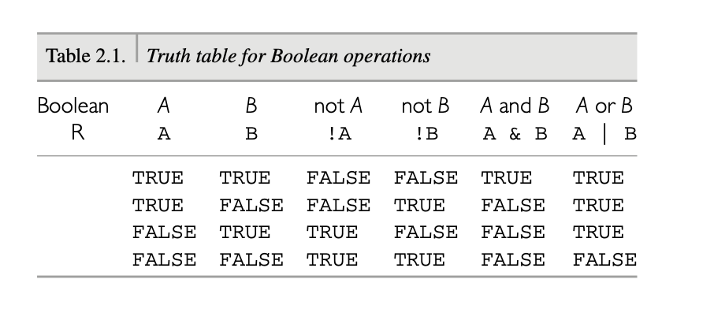

Chapter 2.4.1 Truth Table

Row 1 – A = TRUE, B = TRUE.

Results:

not A → FALSE  
not B → FALSE  
A and B → TRUE (both are TRUE)  
A or B → TRUE (at least one is TRUE)

## Short version

- NOT (!) flips TRUE FALSE
- AND (&) TRUE only when both are TRUE
- OR (|) TRUE when **at least one** is TRUE

## Example

```r
AMAG <- EQ2025[ c(39, 1746, 2, 372), "MAG"]
BQUAL <- EQ2025[ c(39, 1746, 2, 372), "QUALITY"]
AMAG
```

```
[1] 2.61 4.30 1.21 1.23
```

```r
BQUAL
```

```
[1] "A" "D" "A" "C"
```

apply R’s version

```r
!(AMAG >= 2.5)
```

```
[1] FALSE FALSE  TRUE  TRUE
```

```r
(BQUAL != "A")
```

```
[1] FALSE  TRUE FALSE  TRUE
```

```r
(AMAG >= 2.5) & (BQUAL == "A")
```

```
[1]  TRUE FALSE FALSE FALSE
```

```r
(AMAG >= 2.5) | (BQUAL == "A")
```

```
[1]  TRUE  TRUE  TRUE FALSE
```

## The && and ||

- Not tested on this, I don’t ask you to demonstrate its use. But need to know for 102

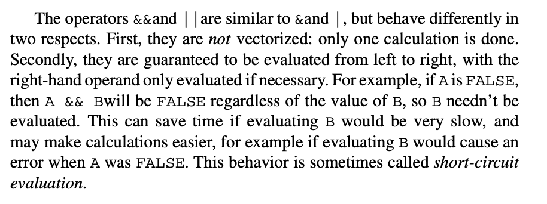

&& and ||

## Summary of Relational Operations

- From Braun & Murdoch

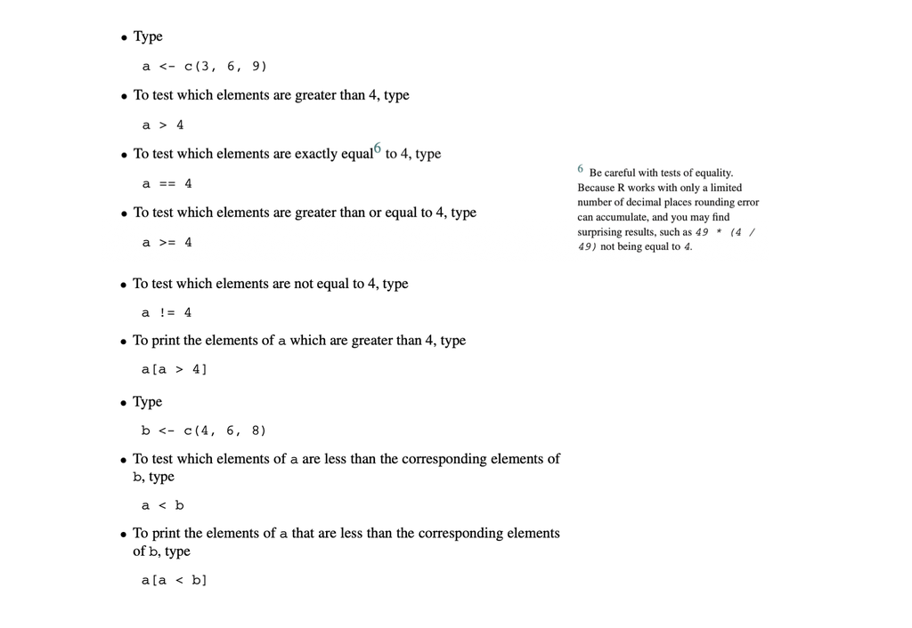

Relational Operator

# Factors

## Factors

- Factors appear to be strings (text data), but are not:

```r
str(iris)
```

```
'data.frame':   150 obs. of  5 variables:
 $ Sepal.Length: num  5.1 4.9 4.7 4.6 5 5.4 4.6 5 4.4 4.9 ...
 $ Sepal.Width : num  3.5 3 3.2 3.1 3.6 3.9 3.4 3.4 2.9 3.1 ...
 $ Petal.Length: num  1.4 1.4 1.3 1.5 1.4 1.7 1.4 1.5 1.4 1.5 ...
 $ Petal.Width : num  0.2 0.2 0.2 0.2 0.2 0.4 0.3 0.2 0.2 0.1 ...
 $ Species     : Factor w/ 3 levels "setosa","versicolor",..: 1 1 1 1 1 1 1 1 1 1 ...
```

```r
head(iris)
```

```
  Sepal.Length Sepal.Width Petal.Length Petal.Width Species
1          5.1         3.5          1.4         0.2  setosa
2          4.9         3.0          1.4         0.2  setosa
3          4.7         3.2          1.3         0.2  setosa
4          4.6         3.1          1.5         0.2  setosa
5          5.0         3.6          1.4         0.2  setosa
6          5.4         3.9          1.7         0.4  setosa
```

- Species in `iris` looks like a string but isn’t

## Factors - What they do

- Factors are variables in R which take on a limited number of different values, typically these variables represent non-numerical or “categorical” information.
- We use factors in statistical modeling because non-numerical variables (e.g., genre — rap, rock, pop, electronic) enter into statistical models differently than numerical variables (one-hot encoding, indicator, dummy coding)
- Designating non-numerical data as factors insures that the more advanced model estimation functions (101ABC) in R will treat these types of variables correctly.
- Factors will also let us order a “categorical” value in any way we wish, not only alphabetically. This is also useful when modeling.

## Example 1: importing csv

- If you were to point and click your way to an import of a .csv file, you might see the following.

[figure not shown]

import

## Example 1: import menu

- Factor is a choice which results in coercion on a string (character) variable

[figure not shown]

result

## Example 1: strings as factor

[figure not shown]

stringsas

## Example 1: result

[figure not shown]

result

## Example 2: another import

- Factors generate “ghost levels”

```r
par(mfrow=c(2,1))

plot1 <- read.csv('http://www.stat.ucla.edu/~vlew/datasets/bom_imdb.csv')

plot1data = plot1[plot1$genre %in%
                      c("Action","Animation","Comedy","Crime","Drama"),]

boxplot(Budget ~ genre, data = plot1data,
        main='genre stored as character', xlab='Movie Genre',
        ylab= 'Budget in million dollars',
        col= c('red','green','blue','cyan','purple'), cex.lab=.65, cex.axis=.65)

plot2 <- read.csv('http://www.stat.ucla.edu/~vlew/datasets/bom_imdb.csv',
                  stringsAsFactors=TRUE)

plot2data = plot2[plot2$genre %in%
                      c("Action","Animation","Comedy","Crime","Drama"),]

boxplot(Budget ~ genre, data= plot2data,
        main='genre stored as factor', xlab='Movie Genre',
        ylab= 'Budget in million dollars',
        col=c('red','green','blue','cyan','purple'), cex.lab=.65, cex.axis=.65)

par(mfrow=c(1,1))
```

## Result

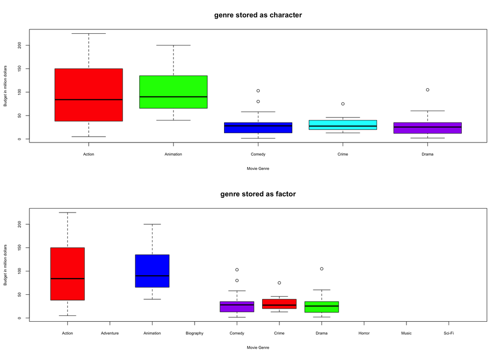

## Note about ggplot

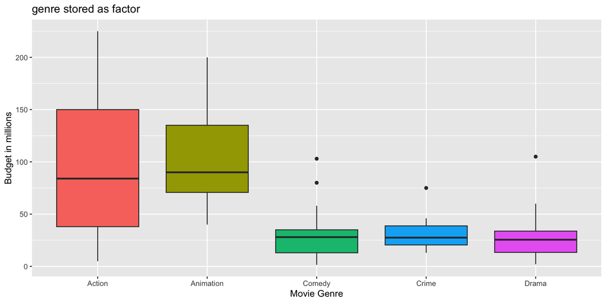

```r
library(ggplot2)
ggplot(plot2data, aes(x = genre, y = Budget, fill = genre)) +
  geom_boxplot() +
  labs(title = 'genre stored as factor', x = 'Movie Genre', y = 'Budget in millions') +
  theme(legend.position ="none")
```

## Thoughtless use of factors

- Read some data, the months are stored as strings, naturally

```r
states <- read.csv(url("http://www.stat.ucla.edu/~vlew/datasets/state_covid_2020.csv"))

str(states)
```

```
'data.frame':   564 obs. of  3 variables:
 $ state: chr  "Alabama" "Alaska" "Arizona" "Arkansas" ...
 $ MONTH: chr  "April" "April" "April" "April" ...
 $ cases: int  7068 353 7648 3281 50470 15207 27700 4734 4323 33683 ...
```

- But do not do this to your audience

```r
boxplot(cases ~ MONTH, data = states, main = "Cases by Month - Original Data",
        xlab = "Month", ylab = "Month")
```

## Thoughtless use of factors - result

- Strings are always alphabetized

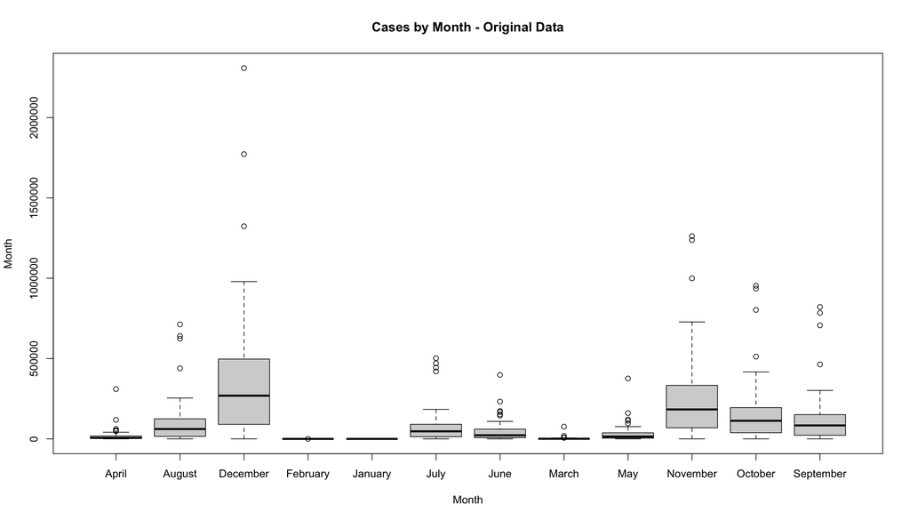

## A possible “fix”

```r
states$MonthF <- factor(states$MONTH,
                        levels=c("January", "February", "March", "April", "May", "June",
                                 "July", "August", "September", "October", "November", "December"))
str(states)
```

```
'data.frame':   564 obs. of  4 variables:
 $ state : chr  "Alabama" "Alaska" "Arizona" "Arkansas" ...
 $ MONTH : chr  "April" "April" "April" "April" ...
 $ cases : int  7068 353 7648 3281 50470 15207 27700 4734 4323 33683 ...
 $ MonthF: Factor w/ 12 levels "January","February",..: 4 4 4 4 4 4 4 4 4 4 ...
```

```r
head(states)
```

```
       state MONTH cases MonthF
1    Alabama April  7068  April
2     Alaska April   353  April
3    Arizona April  7648  April
4   Arkansas April  3281  April
5 California April 50470  April
6   Colorado April 15207  April
```

```r
levels(states$MonthF)
```

```
 [1] "January"   "February"  "March"     "April"     "May"       "June"
 [7] "July"      "August"    "September" "October"   "November"  "December"
```

- result on next slide

```r
boxplot(cases ~ MonthF, data = states, main = "Cases by Month - Ordered Factor",
        xlab = "Month (Factor)", ylab = "Case Count", col = rainbow(12))
```

## A possible “fix” - result

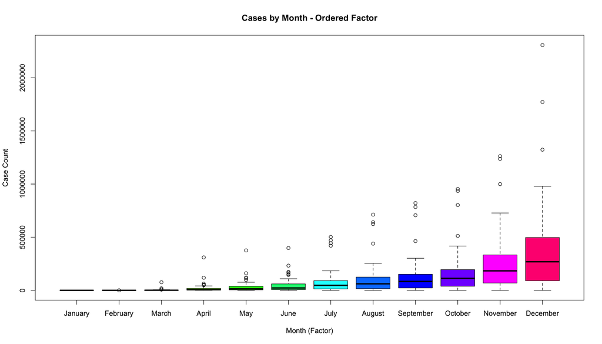

# Dates and Times

## Dates & Times

- Frequently ignored but ever present and often quite useful
- If not told otherwise, R will read data containing dates as we understand them as Character (or worse, Factor)
- Dates (there are exceptions) are stored by R as the number of days or seconds from January 1, 1970, using negative numbers for date before January 1, 1970.
- The default format expected by R is a four digit year, followed by a month, then a day, separated by either dashes or slashes.
- The base R as.Date() function converts character representations of dates (without times, e.g. 1/1/2020)
- The base R strptime() function converts character representations of dates and times to Unix (POSIX) time. This is used when data has times, time zones, AM/PM time stamps, etc.

## Rules of Thumb

- The general rule for date/time data in R is to use the simplest technique possible.
- `as.Date( )` will usually be the best choice because dates typically appear without times. Examples might be trading date, historical dates, birth date. The example from earlier on deaths in the workplace gives dates but not time.
- `strptime( )` would usually be used if there is also a timestamp associated with the date. Generally, data generated by computer, such as a system date, will have a timestamp.
- there are additional base R functiona such as
  - `as.POSIXlt()` - generates a LIST of components (good for extraction like day of the week).
  - `as.POSIXct()` - generates a numeric timestamp (good for computation)

## Examples

The unclass function is only being used to reveal R’s storage of the date (never will ask you about it):

```r
unclass(as.Date("1969-12-30"))
```

```
[1] -2
```

```r
unclass(as.Date("1969/12/31"))
```

```
[1] -1
```

```r
unclass(as.Date("1970/1/1")) # day zero
```

```
[1] 0
```

```r
unclass(as.Date("1970-1-2"))
```

```
[1] 1
```

```r
unclass(as.Date("1970/01/03"))
```

```
[1] 2
```

```r
Sys.Date() # current date
```

```
[1] "2026-04-30"
```

```r
class(Sys.Date())
```

```
[1] "Date"
```

```r
unclass(Sys.Date())  # how R stores it
```

```
[1] 20573
```

## Activity #4 (if there is time)

- Try to calculate the number of days you’ve been alive
- I will select Mr. LeBron James of the Lakers - Dec 30, 1984
- There are other methods of formatting

```r
days_alive <- Sys.Date() - as.Date("1984/12/30")

days_num <- as.numeric(days_alive)

paste(
  "Mr. LeBron James is",
  format(days_num, big.mark = ","), # format() will convert the number to a character
  "days old"
)
```

```
[1] "Mr. LeBron James is 15,096 days old"
```

```r
# NOTE
class(days_num)
```

```
[1] "numeric"
```

```r
format(days_num, big.mark = ",") |> class()
```

```
[1] "character"
```

## Other formats

- The `as.Date()` function allows a variety of input formats through its `format=` argument.
- R can handle virtually any reasonably formatted date by using the `format=`

```r
as.Date("December 21, 2012", format= "%B %d, %Y")
```

```
[1] "2012-12-21"
```

```r
as.Date("Dec 21 2012", format= "%b %d %Y")
```

```
[1] "2012-12-21"
```

```r
as.Date("Dec 21 12", format= "%b %d %y")
```

```
[1] "2012-12-21"
```

```r
as.Date("12DEC21", format= "%y%b%d")
```

```
[1] "2012-12-21"
```

```r
as.Date("21.12.2012", format= "%d.%m.%Y")
```

```
[1] "2012-12-21"
```

```r
as.Date("12/21/2012", format= "%m/%d/%Y")
```

```
[1] "2012-12-21"
```

```r
as.Date("12/21/12", format= "%m/%d/%y")
```

```
[1] "2012-12-21"
```

## Recall date/time formats

- try help(strptime)

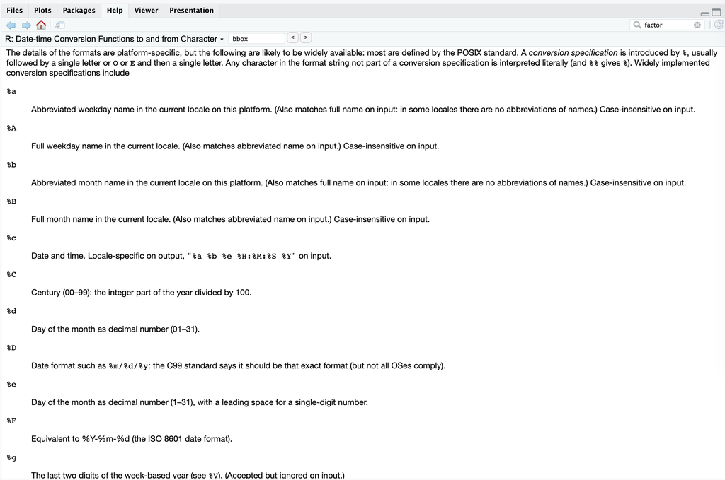

## Time Example

- Recall the Earthquake Data

```r
EQ2025$datetime_text <- paste(EQ2025$DATE, EQ2025$TIME)

EQ2025$timestamp_utc <- as.POSIXct(
  EQ2025$datetime_text,
  format = "%Y/%m/%d %H:%M:%OS",
  tz = "UTC" # 8 hours ahead
)

head(EQ2025[, c(1, 2, 14, 15)])
```

```
        DATE        TIME          datetime_text       timestamp_utc
1 2025/01/01 01:00:56.92 2025/01/01 01:00:56.92 2025-01-01 01:00:56
2 2025/01/01 01:16:28.99 2025/01/01 01:16:28.99 2025-01-01 01:16:28
3 2025/01/01 01:30:49.87 2025/01/01 01:30:49.87 2025-01-01 01:30:49
4 2025/01/01 01:54:51.66 2025/01/01 01:54:51.66 2025-01-01 01:54:51
5 2025/01/01 02:14:01.26 2025/01/01 02:14:01.26 2025-01-01 02:14:01
6 2025/01/01 02:30:22.12 2025/01/01 02:30:22.12 2025-01-01 02:30:22
```

## Put it to use

- There is a library called “lubridate” (you are on your own), instead we can use Base R for most things, like finding the day of the week:

```r
EQ2025$day_of_week <- weekdays(EQ2025$timestamp_utc) # this is a posixct object
head(EQ2025[, c(1, 2, 14:16)])
```

```
        DATE        TIME          datetime_text       timestamp_utc day_of_week
1 2025/01/01 01:00:56.92 2025/01/01 01:00:56.92 2025-01-01 01:00:56   Wednesday
2 2025/01/01 01:16:28.99 2025/01/01 01:16:28.99 2025-01-01 01:16:28   Wednesday
3 2025/01/01 01:30:49.87 2025/01/01 01:30:49.87 2025-01-01 01:30:49   Wednesday
4 2025/01/01 01:54:51.66 2025/01/01 01:54:51.66 2025-01-01 01:54:51   Wednesday
5 2025/01/01 02:14:01.26 2025/01/01 02:14:01.26 2025-01-01 02:14:01   Wednesday
6 2025/01/01 02:30:22.12 2025/01/01 02:30:22.12 2025-01-01 02:30:22   Wednesday
```

```r
table(EQ2025$day_of_week) |> sort()
```

```
 Saturday    Sunday  Thursday    Friday Wednesday   Tuesday    Monday
     2204      2321      2394      2409      2447      2452      2591
```

```r
EQ2025$dowF <- factor(EQ2025$day_of_week,
                        levels=c("Monday", "Tuesday", "Wednesday", "Thursday", "Friday", "Saturday", "Sunday"))
head(EQ2025[, c(1, 2, 14:17)])
```

```
        DATE        TIME          datetime_text       timestamp_utc day_of_week
1 2025/01/01 01:00:56.92 2025/01/01 01:00:56.92 2025-01-01 01:00:56   Wednesday
2 2025/01/01 01:16:28.99 2025/01/01 01:16:28.99 2025-01-01 01:16:28   Wednesday
3 2025/01/01 01:30:49.87 2025/01/01 01:30:49.87 2025-01-01 01:30:49   Wednesday
4 2025/01/01 01:54:51.66 2025/01/01 01:54:51.66 2025-01-01 01:54:51   Wednesday
5 2025/01/01 02:14:01.26 2025/01/01 02:14:01.26 2025-01-01 02:14:01   Wednesday
6 2025/01/01 02:30:22.12 2025/01/01 02:30:22.12 2025-01-01 02:30:22   Wednesday
       dowF
1 Wednesday
2 Wednesday
3 Wednesday
4 Wednesday
5 Wednesday
6 Wednesday
```

## Put it to use 2

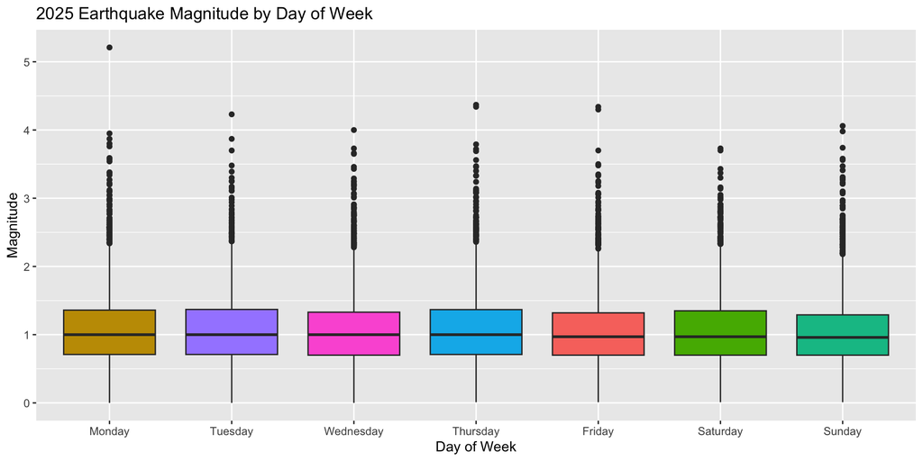

```r
ggplot(data = EQ2025, aes(x = dowF, y = MAG, fill = day_of_week)) +
  geom_boxplot() +
  labs(title = "2025 Earthquake Magnitude by Day of Week", x = "Day of Week", y = "Magnitude") +
  theme(legend.position = "none")
```